# Exploratory Factor Analyses

Alejandra Garcia Isaza

2022-12-23

Datasets on Box folder dated 03.12.22

1MdMMedicinCUIDADORE-AnlisisSPSS03122022_DATA_NOHDRS_2022-12-04_1816.csv -> 238 columnas, 380 filas. Columnas no tienen rotulos de la encuesta, solo V1 - v238

SPSS-RawData Cuidadores 3.12.22.sav -> 243 columnas (pq?), 380 filas. Columnas no tienen rotulos de la encuesta, solo V1 - v238. Muy parecido al anterior, pero si hay algunos datos que difieren.

Base de datos-cuidadores 03.11.22.xlsx -> 236 columnas, 72 filas. Columnas con nombre correcto.

# Loading the dataset (labels, 380 rows, 236 columns)

```r
d_labels <- import(here("nopublish", "SPSS-LabelsData 3.12.22.sav"), setclass = "tbl_df")

d_labels %>%
  arrange(RecordID) # column 97 starts with SDQ
```

```
## # A tibble: 380 x 236
##    Condición RecordID Laencuestaseaplicó Siesotro Cuántosniñostieneenlaescuela
##        <dbl>    <dbl> <chr>                 <dbl> <chr>
##  1         2      201 En papel                 NA 2 o más
##  2         2      202 En papel                 NA 2 o más
##  3         2      203 En papel                 NA 1
##  4         2      204 Por telefono             NA 1
##  5         2      213 En papel                 NA 1
##  6         2      214 En papel                 NA 1
##  7         2      215 En papel                 NA 2 o más
##  8         2      216 En linea                 NA 2 o más
##  9         2      217 En linea                 NA 2 o más
## 10         2      225 En papel                 NA 1
## # ... with 370 more rows, and 231 more variables:
## #   `@1.Cuálessurelaciónconsuniñaoniño` <chr>,
## #   `@1a.Simarcóotrarelaciónporfavorespecifique` <chr>,
## #   `@2.Suniñaoniñoseidentificaconelgénero` <chr>,
## #   `@3.Edaddesuniñaoniñoenaños` <dbl>,
## #   `@4.Enquégradoestásuniñaoniñoenestemomento` <dbl>,
## #   `@5.Esteañoenlaescuelarepetirásuniñaoniñoelgradoen` <chr>, ...
```

# Loading the dataset (raw data, 380 rows, 144 columns (bec. only scales?))

```r
d_raw <- import(here("nopublish", "1MdMMedicinCUIDADORE-AnlisisEscalas051222_DATA_2022-12-05_2032.csv"), setclass = "tbl_df")

d1 <- d_raw %>%
  select(-2:-4)
```

```r
describe(d1) # need to recode values 77 (no aplica), 98 (no estoy segura), 99 (prefiero no responder)
```

```
##                             vars   n   mean     sd median trimmed    mad min
## record_id*                     1 380 190.50 109.84  190.5  190.50 140.85   1
## sdq001_1                       2 376   7.98  24.33    2.0    1.66   0.00   0
## sdq002_1                       3 376   4.70  19.26    1.0    0.79   1.48   0
## sdq003_1                       4 375   3.28  16.67    0.0    0.29   0.00   0
## sdq004_1                       5 376   3.34  14.14    1.0    1.34   1.48   0
## sdq005_1                       6 375   3.09  15.08    1.0    0.70   1.48   0
## sdq006_1                       7 376   3.45  16.63    0.0    0.51   0.00   0
## sdq007_1                       8 376   2.95  12.27    2.0    1.51   0.00   0
## sdq008_1                       9 376   3.13  15.88    0.0    0.44   0.00   0
## sdq009_1                      10 375   2.31   8.72    2.0    1.65   0.00   0
## sdq010_1                      11 376   2.47  13.34    0.0    0.58   0.00   0
## sdq011_1                      12 375   3.87  14.95    2.0    1.67   0.00   0
## sdq012_1                      13 376   2.14  13.37    0.0    0.21   0.00   0
## sdq013_1                      14 376   2.49  14.26    0.0    0.28   0.00   0
## sdq014_1                      15 376   2.71  10.01    2.0    1.76   0.00   0
## sdq015_1                      16 376   2.99  14.20    1.0    0.91   1.48   0
## sdq016_1                      17 376   2.56  13.32    1.0    0.70   1.48   0
## sdq017_1                      18 376   2.75  10.01    2.0    1.83   0.00   0
## sdq018_1                      19 376   3.13  15.88    0.0    0.44   0.00   0
## sdq019_1                      20 375   4.11  18.72    0.0    0.37   0.00   0
## sdq020_1                      21 376   3.03  12.26    2.0    1.59   0.00   0
## sdq021_1                      22 376   1.78   7.15    1.0    1.32   0.74   0
## sdq022_1                      23 376   1.90  13.39    0.0    0.00   0.00   0
## sdq023_1                      24 376   4.00  18.02    0.0    0.56   0.00   0
## sdq024_1                      25 376   3.08  15.06    1.0    0.70   1.48   0
## sdq025_1                      26 375   3.13  13.26    1.0    1.39   1.48   0
## school001_1                   27 376   5.19  11.99    4.0    3.86   0.00   0
## expect001_1                   28 375   3.57  16.64    0.0    0.56   0.00   0
## expect002_1                   29 376   3.46   9.95    3.0    2.58   0.00   0
## expect003_1                   30 375   3.42   8.62    3.0    2.78   0.00   0
## school002_1                   31 376   3.36   0.85    4.0    3.47   0.00   0
## school003_1                   32 376   3.63   4.98    4.0    3.47   0.00   1
## school004_1                   33 376   3.94   7.01    4.0    3.61   0.00   1
## school005_1                   34 376   3.57   7.07    3.0    3.23   1.48   0
## school006_1                   35 375   4.49   6.97    4.0    4.13   1.48   0
## pafas001_1                    36 375   3.30  15.89    0.0    0.56   0.00   0
## pafas002_1                    37 375   3.81  14.11    2.0    1.83   1.48   0
## pafas003_1                    38 375   3.32  11.18    2.0    2.16   1.48   0
## pafas004_1                    39 375   2.80  13.33    1.0    0.89   1.48   0
```

[output cut: 229 more lines]

```
## relpar001_1                  99    99  6.28    38.43 0.70
## relpar002_1                  99    99  5.66    30.77 0.77
## relpar003_1                  99    99  5.95    34.36 0.73
## relpar004_1                  99    99  5.16    25.28 0.83
## relpar005_1                  99    99  5.32    26.72 0.86
## relpar006_1                  99    99  5.69    31.01 0.76
## safeneigh001_1               99    99  5.53    28.76 0.85
## safeneigh002_1               99    99  4.07    14.62 1.11
## safeneigh003_1               99    99  5.53    28.77 0.85
## safeneigh004_1               99    99  7.02    47.79 0.69
## safeneigh005_1               99    99  7.60    56.40 0.64
## safeneigh006_1               99    99  5.81    32.08 0.81
## safeneigh007_1               99    99  7.05    48.03 0.68
## safeneigh008_1               99    99  7.63    56.71 0.63
## encuestacuidadores_complete   2     2 -5.83    33.74 0.02
```

# recoding missing variables as N/A

```r
describe(d2) # adequately recoded.
```

```
##                             vars   n   mean     sd median trimmed    mad min
## record_id*                     1 380 190.50 109.84  190.5  190.50 140.85   1
## sdq001_1                       2 351   1.50   0.70    2.0    1.62   0.00   0
## sdq002_1                       3 361   0.79   0.78    1.0    0.73   1.48   0
## sdq003_1                       4 364   0.38   0.62    0.0    0.26   0.00   0
## sdq004_1                       5 368   1.26   0.75    1.0    1.32   1.48   0
## sdq005_1                       6 366   0.73   0.79    1.0    0.66   1.48   0
## sdq006_1                       7 365   0.57   0.77    0.0    0.46   0.00   0
## sdq007_1                       8 370   1.40   0.70    2.0    1.50   0.00   0
## sdq008_1                       9 366   0.51   0.69    0.0    0.39   0.00   0
## sdq009_1                      10 372   1.53   0.65    2.0    1.65   0.00   0
## sdq010_1                      11 369   0.64   0.77    0.0    0.55   0.00   0
## sdq011_1                      12 366   1.53   0.67    2.0    1.66   0.00   0
## sdq012_1                      13 369   0.30   0.57    0.0    0.19   0.00   0
## sdq013_1                      14 368   0.39   0.65    0.0    0.25   0.00   0
## sdq014_1                      15 372   1.68   0.53    2.0    1.76   0.00   0
## sdq015_1                      16 368   0.90   0.80    1.0    0.88   1.48   0
## sdq016_1                      17 369   0.73   0.78    1.0    0.67   1.48   0
## sdq017_1                      18 372   1.72   0.54    2.0    1.83   0.00   0
## sdq018_1                      19 366   0.51   0.64    0.0    0.42   0.00   0
## sdq019_1                      20 361   0.43   0.66    0.0    0.30   0.00   0
## sdq020_1                      21 370   1.47   0.67    2.0    1.58   0.00   0
## sdq021_1                      22 374   1.26   0.66    1.0    1.32   0.00   0
## sdq022_1                      23 369   0.06   0.29    0.0    0.00   0.00   0
## sdq023_1                      24 363   0.60   0.76    0.0    0.50   0.00   0
## sdq024_1                      25 367   0.73   0.79    1.0    0.66   1.48   0
## sdq025_1                      26 368   1.30   0.73    1.0    1.38   1.48   0
## school001_1                   27 370   3.66   0.74    4.0    3.85   0.00   0
## expect001_1                   28 364   0.68   1.05    0.0    0.48   0.00   0
## expect002_1                   29 372   2.44   0.75    3.0    2.57   0.00   0
## expect003_1                   30 372   2.65   0.61    3.0    2.78   0.00   0
## school002_1                   31 376   3.36   0.85    4.0    3.47   0.00   0
## school003_1                   32 375   3.38   0.72    4.0    3.47   0.00   1
## school004_1                   33 374   3.44   0.86    4.0    3.61   0.00   1
## school005_1                   34 374   3.06   1.09    3.0    3.22   1.48   0
## school006_1                   35 373   3.99   1.02    4.0    4.13   1.48   0
## pafas001_1                    36 365   0.68   0.95    0.0    0.50   0.00   0
## pafas002_1                    37 367   1.74   1.06    2.0    1.79   1.48   0
## pafas003_1                    38 370   2.03   0.98    2.0    2.15   1.48   0
## pafas004_1                    39 368   0.97   1.10    1.0    0.84   1.48   0
```

[output cut: 229 more lines]

```
## relpar001_1                   3     3  0.16    -1.27 0.06
## relpar002_1                   3     3 -0.16    -1.25 0.05
## relpar003_1                   3     3  0.41    -1.15 0.06
## relpar004_1                   3     3 -0.10    -1.49 0.06
## relpar005_1                   3     3 -0.04    -1.52 0.06
## relpar006_1                   3     3 -1.69     2.22 0.03
## safeneigh001_1                3     3  0.05    -1.33 0.06
## safeneigh002_1                3     3  0.97    -0.34 0.05
## safeneigh003_1                3     3  0.70    -0.94 0.06
## safeneigh004_1                3     3  0.51    -1.04 0.06
## safeneigh005_1                3     3  0.37    -1.23 0.06
## safeneigh006_1                3     3  0.10    -1.39 0.06
## safeneigh007_1                3     3 -0.88    -0.20 0.04
## safeneigh008_1                3     3 -0.94    -0.13 0.05
## encuestacuidadores_complete   2     2 -5.83    33.74 0.02
```

# Data prep: reverse scoring negatively worded items

```r
d3 <- d2 %>%
  mutate(sdq007_1 = likert_reverse(sdq007_1, top = 2, bottom = 0),
         sdq011_1 = likert_reverse(sdq011_1, top = 2, bottom = 0),
         sdq014_1 = likert_reverse(sdq014_1, top = 2, bottom = 0),
         sdq021_1 = likert_reverse(sdq021_1, top = 2, bottom = 0),
         sdq025_1 = likert_reverse(sdq025_1, top = 2, bottom = 0))
```

# SDQ

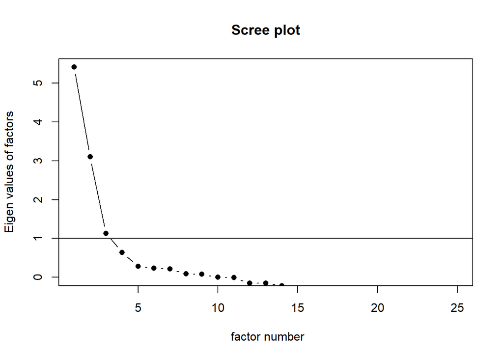

```r
# SDQ (25 items)
sdq <- d3 %>%
  select(sdq001_1:sdq025_1)

# Poly corr matrix
poly_sdq <- polychoric(sdq)
poly_sdq_mat <- data.frame(poly_sdq$rho)

# scree plot
scree(poly_sdq_mat,factors=TRUE,pc=FALSE,main="Scree plot",hline=NULL,add=FALSE)
```

```r
# EFA
fa(sdq, n.obs = NA, rotate = "none", fm = "uls", cor = "poly")
```

```
## Factor Analysis using method =  uls
## Call: fa(r = sdq, n.obs = NA, rotate = "none", fm = "uls", cor = "poly")
## Standardized loadings (pattern matrix) based upon correlation matrix
##           ULS1    h2   u2 com
## sdq001_1 -0.18 0.032 0.97   1
## sdq002_1  0.59 0.351 0.65   1
## sdq003_1  0.40 0.160 0.84   1
## sdq004_1 -0.12 0.014 0.99   1
## sdq005_1  0.70 0.492 0.51   1
## sdq006_1  0.22 0.048 0.95   1
## sdq007_1  0.44 0.190 0.81   1
## sdq008_1  0.62 0.388 0.61   1
## sdq009_1 -0.20 0.040 0.96   1
## sdq010_1  0.58 0.337 0.66   1
## sdq011_1  0.31 0.095 0.91   1
## sdq012_1  0.67 0.454 0.55   1
## sdq013_1  0.65 0.419 0.58   1
## sdq014_1  0.27 0.071 0.93   1
## sdq015_1  0.56 0.311 0.69   1
## sdq016_1  0.47 0.224 0.78   1
## sdq017_1 -0.38 0.146 0.85   1
## sdq018_1  0.59 0.347 0.65   1
## sdq019_1  0.51 0.256 0.74   1
## sdq020_1 -0.28 0.077 0.92   1
## sdq021_1  0.50 0.248 0.75   1
## sdq022_1  0.48 0.230 0.77   1
## sdq023_1  0.24 0.058 0.94   1
## sdq024_1  0.37 0.140 0.86   1
## sdq025_1  0.53 0.285 0.71   1
##
##                ULS1
## SS loadings    5.41
## Proportion Var 0.22
##
## Mean item complexity =  1
## Test of the hypothesis that 1 factor is sufficient.
##
## The degrees of freedom for the null model are  300  and the objective function was  11.73 with Chi Square of  4337.86
## The degrees of freedom for the model are 275  and the objective function was  7.38
##
## The root mean square of the residuals (RMSR) is  0.15
## The df corrected root mean square of the residuals is  0.16
##
## The harmonic number of observations is  361 with the empirical chi square  5161.84  with prob <  0
## The total number of observations was  380  with Likelihood Chi Square =  2722.86  with prob <  0
##
## Tucker Lewis Index of factoring reliability =  0.337
## RMSEA index =  0.153  and the 90 % confidence intervals are  0.148 0.159
## BIC =  1089.31
## Fit based upon off diagonal values = 0.66
## Measures of factor score adequacy
##                                                   ULS1
## Correlation of (regression) scores with factors   0.94
## Multiple R square of scores with factors          0.89
## Minimum correlation of possible factor scores     0.78
```

```
## In smc, smcs < 0 were set to .0
## In smc, smcs < 0 were set to .0
```

```
## In smc, smcs < 0 were set to .0
## In smc, smcs < 0 were set to .0
```

```
## In smc, smcs < 0 were set to .0
## In smc, smcs < 0 were set to .0
```

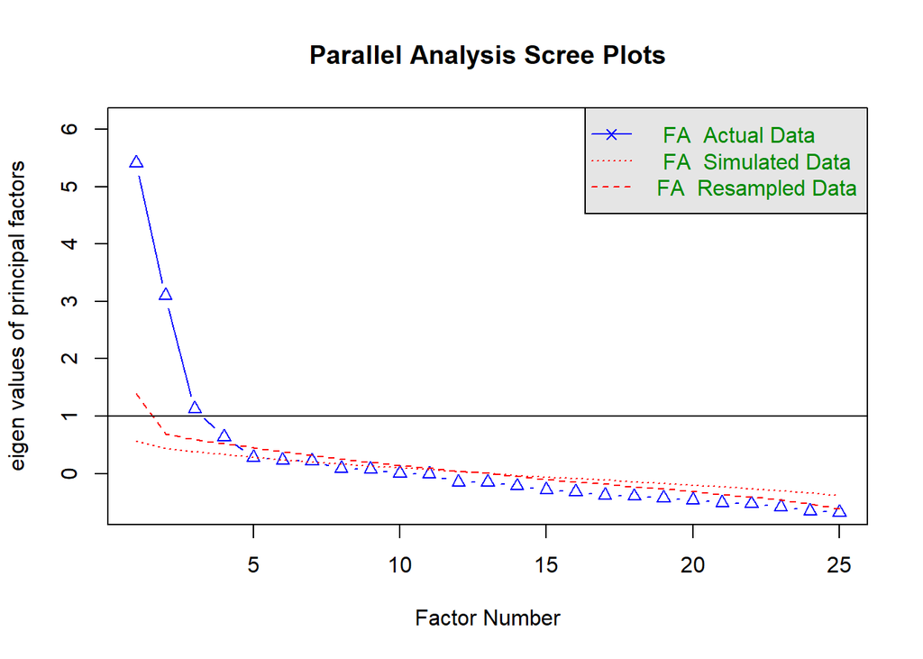

```
## Parallel analysis suggests that the number of factors =  4  and the number of components =  NA
```

```r
# PARALLEL ANALYSIS
fa.parallel(sdq, n.obs=NULL, fm="uls", fa="fa", nfactors=1, main="Parallel Analysis Scree Plots", n.iter=20, error.bars=FALSE, se.bars=FALSE, SMC=FALSE, ylabel=NULL, show.legend=TRUE, sim=TRUE, quant=.95, cor="poly", use="pairwise", plot=TRUE, correct=.5) # suggest 4 factors
```

```r
# 4 factors
fa(sdq, nfactors = 4, n.obs = NA, rotate = "quartimin", fm = "uls", cor = "poly")
```

```
## Factor Analysis using method =  uls
## Call: fa(r = sdq, nfactors = 4, n.obs = NA, rotate = "quartimin", fm = "uls",
##     cor = "poly")
## Standardized loadings (pattern matrix) based upon correlation matrix
##           ULS2  ULS3  ULS1  ULS4   h2   u2 com
## sdq001_1 -0.55 -0.01 -0.08  0.37 0.41 0.59 1.8
## sdq002_1  0.00 -0.04  0.69  0.14 0.53 0.47 1.1
## sdq003_1  0.02  0.37  0.19 -0.06 0.22 0.78 1.6
## sdq004_1 -0.51 -0.10  0.15  0.17 0.26 0.74 1.5
## sdq005_1  0.01  0.21  0.66  0.00 0.59 0.41 1.2
## sdq006_1 -0.02  0.51 -0.07 -0.14 0.25 0.75 1.2
## sdq007_1  0.56 -0.01  0.13  0.19 0.43 0.57 1.4
## sdq008_1  0.06  0.56  0.20  0.12 0.49 0.51 1.4
## sdq009_1 -0.71  0.04  0.10  0.06 0.48 0.52 1.1
## sdq010_1 -0.10 -0.09  0.85  0.03 0.66 0.34 1.0
## sdq011_1  0.64  0.13 -0.18  0.18 0.43 0.57 1.4
## sdq012_1  0.15  0.16  0.66 -0.14 0.57 0.43 1.3
## sdq013_1  0.04  0.60  0.19  0.17 0.56 0.44 1.4
## sdq014_1  0.72 -0.01 -0.06 -0.03 0.50 0.50 1.0
## sdq015_1 -0.10  0.33  0.27  0.44 0.53 0.47 2.7
## sdq016_1  0.01  0.74 -0.08  0.11 0.54 0.46 1.1
## sdq017_1 -0.70  0.17 -0.23  0.02 0.61 0.39 1.3
## sdq018_1  0.07  0.25  0.39  0.15 0.36 0.64 2.1
## sdq019_1  0.01  0.47  0.16  0.12 0.34 0.66 1.4
## sdq020_1 -0.57  0.15 -0.03 -0.22 0.43 0.57 1.4
## sdq021_1  0.37  0.02  0.23  0.31 0.39 0.61 2.7
## sdq022_1  0.32  0.23  0.35 -0.28 0.38 0.62 3.7
## sdq023_1  0.10  0.45 -0.10 -0.08 0.18 0.82 1.3
## sdq024_1 -0.15  0.80 -0.02 -0.13 0.64 0.36 1.1
## sdq025_1  0.33  0.11  0.13  0.52 0.52 0.48 1.9
##
##                       ULS2 ULS3 ULS1 ULS4
## SS loadings           3.63 3.30 3.14 1.23
## Proportion Var        0.15 0.13 0.13 0.05
## Cumulative Var        0.15 0.28 0.40 0.45
## Proportion Explained  0.32 0.29 0.28 0.11
## Cumulative Proportion 0.32 0.61 0.89 1.00
##
##  With factor correlations of
##       ULS2  ULS3 ULS1 ULS4
```

[output cut: 11 more lines]

```
## The root mean square of the residuals (RMSR) is  0.05
## The df corrected root mean square of the residuals is  0.06
##
## The harmonic number of observations is  361 with the empirical chi square  528.73  with prob <  3e-30
## The total number of observations was  380  with Likelihood Chi Square =  1083.43  with prob <  4.9e-119
##
## Tucker Lewis Index of factoring reliability =  0.681
## RMSEA index =  0.106  and the 90 % confidence intervals are  0.1 0.112
## BIC =  -140.24
## Fit based upon off diagonal values = 0.97
## Measures of factor score adequacy
##                                                   ULS2 ULS3 ULS1 ULS4
## Correlation of (regression) scores with factors   0.93 0.93 0.93 0.82
## Multiple R square of scores with factors          0.87 0.87 0.87 0.68
## Minimum correlation of possible factor scores     0.74 0.73 0.74 0.36
```

# SDQ withoutout prosocial scale

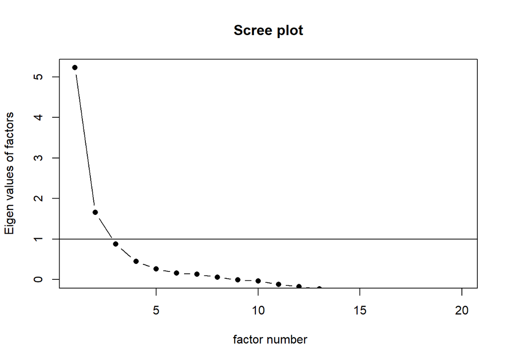

```r
# SDQ (25 items)
sdq_2 <- d3 %>%
  select(sdq001_1:sdq025_1) %>%
  select(-sdq001_1, -sdq004_1, -sdq009_1, -sdq017_1, -sdq020_1)

# Poly corr matrix
poly_sdq_2 <- polychoric(sdq_2)
poly_sdq_2_mat <- data.frame(poly_sdq_2$rho)

# scree plot
scree(poly_sdq_2_mat,factors=TRUE,pc=FALSE,main="Scree plot",hline=NULL,add=FALSE)
```

```r
# EFA
fa(sdq_2, n.obs = NA, rotate = "none", fm = "uls", cor = "poly")
```

```
## Factor Analysis using method =  uls
## Call: fa(r = sdq_2, n.obs = NA, rotate = "none", fm = "uls", cor = "poly")
## Standardized loadings (pattern matrix) based upon correlation matrix
##          ULS1    h2   u2 com
## sdq002_1 0.59 0.343 0.66   1
## sdq003_1 0.43 0.186 0.81   1
## sdq005_1 0.72 0.519 0.48   1
## sdq006_1 0.26 0.070 0.93   1
## sdq007_1 0.33 0.112 0.89   1
## sdq008_1 0.67 0.450 0.55   1
## sdq010_1 0.59 0.348 0.65   1
## sdq011_1 0.21 0.045 0.95   1
## sdq012_1 0.65 0.428 0.57   1
## sdq013_1 0.71 0.498 0.50   1
## sdq014_1 0.14 0.021 0.98   1
## sdq015_1 0.61 0.374 0.63   1
## sdq016_1 0.53 0.286 0.71   1
## sdq018_1 0.60 0.360 0.64   1
## sdq019_1 0.55 0.302 0.70   1
## sdq021_1 0.43 0.182 0.82   1
## sdq022_1 0.43 0.189 0.81   1
## sdq023_1 0.27 0.071 0.93   1
## sdq024_1 0.47 0.218 0.78   1
## sdq025_1 0.48 0.229 0.77   1
##
##                ULS1
## SS loadings    5.23
## Proportion Var 0.26
##
## Mean item complexity =  1
## Test of the hypothesis that 1 factor is sufficient.
##
## The degrees of freedom for the null model are  190  and the objective function was  8.37 with Chi Square of  3110.18
## The degrees of freedom for the model are 170  and the objective function was  4.11
##
## The root mean square of the residuals (RMSR) is  0.12
## The df corrected root mean square of the residuals is  0.13
##
## The harmonic number of observations is  362 with the empirical chi square  1944.48  with prob <  1.8e-298
## The total number of observations was  380  with Likelihood Chi Square =  1522.5  with prob <  9.4e-216
##
## Tucker Lewis Index of factoring reliability =  0.481
## RMSEA index =  0.145  and the 90 % confidence intervals are  0.138 0.152
## BIC =  512.67
## Fit based upon off diagonal values = 0.83
## Measures of factor score adequacy
##                                                   ULS1
## Correlation of (regression) scores with factors   0.94
## Multiple R square of scores with factors          0.89
## Minimum correlation of possible factor scores     0.79
```

```
## In smc, smcs < 0 were set to .0
## In smc, smcs < 0 were set to .0
```

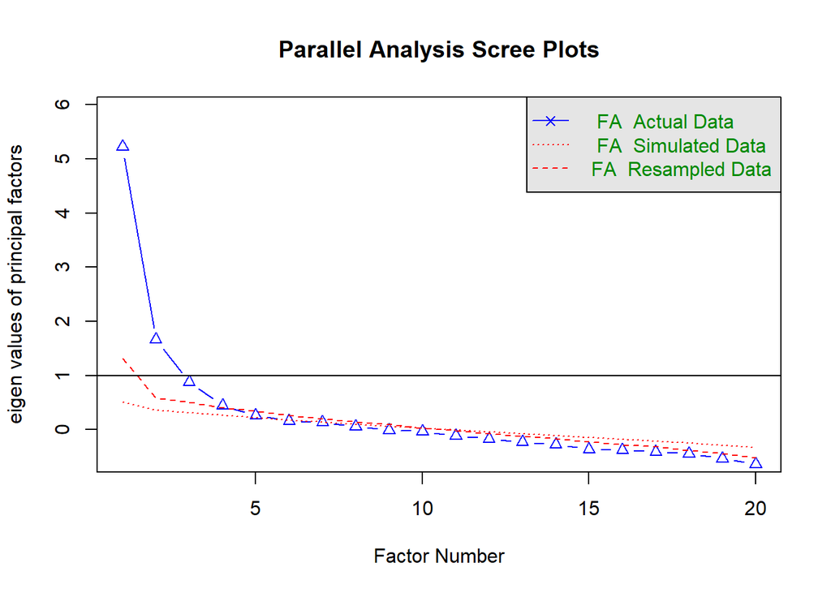

```
## Parallel analysis suggests that the number of factors =  5  and the number of components =  NA
```

```r
# PARALLEL ANALYSIS - without prosocial scale
fa.parallel(sdq_2, n.obs=NULL, fm="uls", fa="fa", nfactors=1, main="Parallel Analysis Scree Plots", n.iter=20, error.bars=FALSE, se.bars=FALSE, SMC=FALSE, ylabel=NULL, show.legend=TRUE, sim=TRUE, quant=.95, cor="poly", use="pairwise", plot=TRUE, correct=.5) # suggest 5 factors
```

```r
# 4 factors
fa(sdq_2, nfactors = 4, n.obs = NA, rotate = "quartimin", fm = "uls", cor = "poly")
```

```
## Factor Analysis using method =  uls
## Call: fa(r = sdq_2, nfactors = 4, n.obs = NA, rotate = "quartimin",
##     fm = "uls", cor = "poly")
## Standardized loadings (pattern matrix) based upon correlation matrix
##           ULS3  ULS1  ULS2  ULS4   h2   u2 com
## sdq002_1 -0.05  0.69  0.06  0.12 0.52 0.48 1.1
## sdq003_1  0.36  0.20  0.04 -0.14 0.23 0.77 1.9
## sdq005_1  0.20  0.66  0.02 -0.01 0.59 0.41 1.2
## sdq006_1  0.51 -0.05 -0.13 -0.08 0.25 0.75 1.2
## sdq007_1 -0.08  0.14  0.62  0.01 0.45 0.55 1.1
## sdq008_1  0.55  0.22  0.16 -0.05 0.49 0.51 1.5
## sdq010_1 -0.11  0.88 -0.10  0.04 0.69 0.31 1.1
## sdq011_1  0.03 -0.17  0.72  0.05 0.47 0.53 1.1
## sdq012_1  0.13  0.68  0.06 -0.16 0.56 0.44 1.2
## sdq013_1  0.59  0.20  0.17  0.00 0.55 0.45 1.4
## sdq014_1 -0.09 -0.07  0.69 -0.18 0.48 0.52 1.2
## sdq015_1  0.33  0.29  0.03  0.45 0.56 0.44 2.6
## sdq016_1  0.77 -0.09  0.00  0.18 0.61 0.39 1.1
## sdq018_1  0.22  0.40  0.11  0.17 0.38 0.62 2.1
## sdq019_1  0.48  0.13  0.11  0.07 0.34 0.66 1.3
## sdq021_1 -0.02  0.23  0.41  0.27 0.38 0.62 2.4
## sdq022_1  0.19  0.34  0.22 -0.38 0.38 0.62 3.1
## sdq023_1  0.41 -0.07  0.09 -0.12 0.17 0.83 1.3
## sdq024_1  0.82 -0.05 -0.16 -0.08 0.64 0.36 1.1
## sdq025_1  0.08  0.17  0.45  0.27 0.42 0.58 2.1
##
##                       ULS3 ULS1 ULS2 ULS4
## SS loadings           3.22 3.15 2.06 0.73
## Proportion Var        0.16 0.16 0.10 0.04
## Cumulative Var        0.16 0.32 0.42 0.46
## Proportion Explained  0.35 0.34 0.23 0.08
## Cumulative Proportion 0.35 0.70 0.92 1.00
##
##  With factor correlations of
##      ULS3 ULS1 ULS2 ULS4
## ULS3 1.00 0.38 0.10 0.11
## ULS1 0.38 1.00 0.30 0.18
## ULS2 0.10 0.30 1.00 0.05
## ULS4 0.11 0.18 0.05 1.00
##
## Mean item complexity =  1.6
## Test of the hypothesis that 4 factors are sufficient.
##
## The degrees of freedom for the null model are  190  and the objective function was  8.37 with Chi Square of  3110.18
## The degrees of freedom for the model are 116  and the objective function was  1.69
##
## The root mean square of the residuals (RMSR) is  0.05
## The df corrected root mean square of the residuals is  0.06
##
## The harmonic number of observations is  362 with the empirical chi square  295.13  with prob <  1.4e-17
## The total number of observations was  380  with Likelihood Chi Square =  622.57  with prob <  2.5e-70
##
## Tucker Lewis Index of factoring reliability =  0.714
## RMSEA index =  0.107  and the 90 % confidence intervals are  0.099 0.116
## BIC =  -66.49
## Fit based upon off diagonal values = 0.97
## Measures of factor score adequacy
##                                                   ULS3 ULS1 ULS2 ULS4
## Correlation of (regression) scores with factors   0.93 0.94 0.89 0.76
## Multiple R square of scores with factors          0.87 0.88 0.79 0.58
## Minimum correlation of possible factor scores     0.74 0.75 0.57 0.15
```

# Exploratory Factor Analyses

Alejandra Garcia Isaza

2022-12-23

Datasets on Box folder dated 03.12.22

1MdMMedicinCUIDADORE-AnlisisSPSS03122022_DATA_NOHDRS_2022-12-04_1816.csv -> 238 columnas, 380 filas. Columnas no tienen rotulos de la encuesta, solo V1 - v238

SPSS-RawData Cuidadores 3.12.22.sav -> 243 columnas (pq?), 380 filas. Columnas no tienen rotulos de la encuesta, solo V1 - v238. Muy parecido al anterior, pero si hay algunos datos que difieren.

Base de datos-cuidadores 03.11.22.xlsx -> 236 columnas, 72 filas. Columnas con nombre correcto.

# Loading the dataset (labels, 380 rows, 236 columns)

```r
d_labels <- import(here("nopublish", "SPSS-LabelsData 3.12.22.sav"), setclass = "tbl_df")

d_labels %>%
  arrange(RecordID) # column 97 starts with SDQ
```

```
## # A tibble: 380 x 236
##    Condición RecordID Laencuestaseaplicó Siesotro Cuántosniñostieneenlaescuela
##        <dbl>    <dbl> <chr>                 <dbl> <chr>
##  1         2      201 En papel                 NA 2 o más
##  2         2      202 En papel                 NA 2 o más
##  3         2      203 En papel                 NA 1
##  4         2      204 Por telefono             NA 1
##  5         2      213 En papel                 NA 1
##  6         2      214 En papel                 NA 1
##  7         2      215 En papel                 NA 2 o más
##  8         2      216 En linea                 NA 2 o más
##  9         2      217 En linea                 NA 2 o más
## 10         2      225 En papel                 NA 1
## # ... with 370 more rows, and 231 more variables:
## #   `@1.Cuálessurelaciónconsuniñaoniño` <chr>,
## #   `@1a.Simarcóotrarelaciónporfavorespecifique` <chr>,
## #   `@2.Suniñaoniñoseidentificaconelgénero` <chr>,
## #   `@3.Edaddesuniñaoniñoenaños` <dbl>,
## #   `@4.Enquégradoestásuniñaoniñoenestemomento` <dbl>,
## #   `@5.Esteañoenlaescuelarepetirásuniñaoniñoelgradoen` <chr>, ...
```

# Loading the dataset (raw data, 380 rows, 144 columns (bec. only scales?))

```r
d_raw <- import(here("nopublish", "1MdMMedicinCUIDADORE-AnlisisEscalas051222_DATA_2022-12-05_2032.csv"), setclass = "tbl_df")

d1 <- d_raw %>%
  select(-2:-4)
```

```r
describe(d1) # need to recode values 77 (no aplica), 98 (no estoy segura), 99 (prefiero no responder)
```

```
##                             vars   n   mean     sd median trimmed    mad min
## record_id*                     1 380 190.50 109.84  190.5  190.50 140.85   1
## sdq001_1                       2 376   7.98  24.33    2.0    1.66   0.00   0
## sdq002_1                       3 376   4.70  19.26    1.0    0.79   1.48   0
## sdq003_1                       4 375   3.28  16.67    0.0    0.29   0.00   0
## sdq004_1                       5 376   3.34  14.14    1.0    1.34   1.48   0
## sdq005_1                       6 375   3.09  15.08    1.0    0.70   1.48   0
## sdq006_1                       7 376   3.45  16.63    0.0    0.51   0.00   0
## sdq007_1                       8 376   2.95  12.27    2.0    1.51   0.00   0
## sdq008_1                       9 376   3.13  15.88    0.0    0.44   0.00   0
## sdq009_1                      10 375   2.31   8.72    2.0    1.65   0.00   0
## sdq010_1                      11 376   2.47  13.34    0.0    0.58   0.00   0
## sdq011_1                      12 375   3.87  14.95    2.0    1.67   0.00   0
## sdq012_1                      13 376   2.14  13.37    0.0    0.21   0.00   0
## sdq013_1                      14 376   2.49  14.26    0.0    0.28   0.00   0
## sdq014_1                      15 376   2.71  10.01    2.0    1.76   0.00   0
## sdq015_1                      16 376   2.99  14.20    1.0    0.91   1.48   0
## sdq016_1                      17 376   2.56  13.32    1.0    0.70   1.48   0
## sdq017_1                      18 376   2.75  10.01    2.0    1.83   0.00   0
## sdq018_1                      19 376   3.13  15.88    0.0    0.44   0.00   0
## sdq019_1                      20 375   4.11  18.72    0.0    0.37   0.00   0
## sdq020_1                      21 376   3.03  12.26    2.0    1.59   0.00   0
## sdq021_1                      22 376   1.78   7.15    1.0    1.32   0.74   0
## sdq022_1                      23 376   1.90  13.39    0.0    0.00   0.00   0
## sdq023_1                      24 376   4.00  18.02    0.0    0.56   0.00   0
## sdq024_1                      25 376   3.08  15.06    1.0    0.70   1.48   0
## sdq025_1                      26 375   3.13  13.26    1.0    1.39   1.48   0
## school001_1                   27 376   5.19  11.99    4.0    3.86   0.00   0
## expect001_1                   28 375   3.57  16.64    0.0    0.56   0.00   0
## expect002_1                   29 376   3.46   9.95    3.0    2.58   0.00   0
## expect003_1                   30 375   3.42   8.62    3.0    2.78   0.00   0
## school002_1                   31 376   3.36   0.85    4.0    3.47   0.00   0
## school003_1                   32 376   3.63   4.98    4.0    3.47   0.00   1
## school004_1                   33 376   3.94   7.01    4.0    3.61   0.00   1
## school005_1                   34 376   3.57   7.07    3.0    3.23   1.48   0
## school006_1                   35 375   4.49   6.97    4.0    4.13   1.48   0
## pafas001_1                    36 375   3.30  15.89    0.0    0.56   0.00   0
## pafas002_1                    37 375   3.81  14.11    2.0    1.83   1.48   0
## pafas003_1                    38 375   3.32  11.18    2.0    2.16   1.48   0
## pafas004_1                    39 375   2.80  13.33    1.0    0.89   1.48   0
```

[output cut: 229 more lines]

```
## relpar001_1                  99    99  6.28    38.43 0.70
## relpar002_1                  99    99  5.66    30.77 0.77
## relpar003_1                  99    99  5.95    34.36 0.73
## relpar004_1                  99    99  5.16    25.28 0.83
## relpar005_1                  99    99  5.32    26.72 0.86
## relpar006_1                  99    99  5.69    31.01 0.76
## safeneigh001_1               99    99  5.53    28.76 0.85
## safeneigh002_1               99    99  4.07    14.62 1.11
## safeneigh003_1               99    99  5.53    28.77 0.85
## safeneigh004_1               99    99  7.02    47.79 0.69
## safeneigh005_1               99    99  7.60    56.40 0.64
## safeneigh006_1               99    99  5.81    32.08 0.81
## safeneigh007_1               99    99  7.05    48.03 0.68
## safeneigh008_1               99    99  7.63    56.71 0.63
## encuestacuidadores_complete   2     2 -5.83    33.74 0.02
```

# recoding missing variables as N/A

```r
describe(d2) # adequately recoded.
```

```
##                             vars   n   mean     sd median trimmed    mad min
## record_id*                     1 380 190.50 109.84  190.5  190.50 140.85   1
## sdq001_1                       2 351   1.50   0.70    2.0    1.62   0.00   0
## sdq002_1                       3 361   0.79   0.78    1.0    0.73   1.48   0
## sdq003_1                       4 364   0.38   0.62    0.0    0.26   0.00   0
## sdq004_1                       5 368   1.26   0.75    1.0    1.32   1.48   0
## sdq005_1                       6 366   0.73   0.79    1.0    0.66   1.48   0
## sdq006_1                       7 365   0.57   0.77    0.0    0.46   0.00   0
## sdq007_1                       8 370   1.40   0.70    2.0    1.50   0.00   0
## sdq008_1                       9 366   0.51   0.69    0.0    0.39   0.00   0
## sdq009_1                      10 372   1.53   0.65    2.0    1.65   0.00   0
## sdq010_1                      11 369   0.64   0.77    0.0    0.55   0.00   0
## sdq011_1                      12 366   1.53   0.67    2.0    1.66   0.00   0
## sdq012_1                      13 369   0.30   0.57    0.0    0.19   0.00   0
## sdq013_1                      14 368   0.39   0.65    0.0    0.25   0.00   0
## sdq014_1                      15 372   1.68   0.53    2.0    1.76   0.00   0
## sdq015_1                      16 368   0.90   0.80    1.0    0.88   1.48   0
## sdq016_1                      17 369   0.73   0.78    1.0    0.67   1.48   0
## sdq017_1                      18 372   1.72   0.54    2.0    1.83   0.00   0
## sdq018_1                      19 366   0.51   0.64    0.0    0.42   0.00   0
## sdq019_1                      20 361   0.43   0.66    0.0    0.30   0.00   0
## sdq020_1                      21 370   1.47   0.67    2.0    1.58   0.00   0
## sdq021_1                      22 374   1.26   0.66    1.0    1.32   0.00   0
## sdq022_1                      23 369   0.06   0.29    0.0    0.00   0.00   0
## sdq023_1                      24 363   0.60   0.76    0.0    0.50   0.00   0
## sdq024_1                      25 367   0.73   0.79    1.0    0.66   1.48   0
## sdq025_1                      26 368   1.30   0.73    1.0    1.38   1.48   0
## school001_1                   27 370   3.66   0.74    4.0    3.85   0.00   0
## expect001_1                   28 364   0.68   1.05    0.0    0.48   0.00   0
## expect002_1                   29 372   2.44   0.75    3.0    2.57   0.00   0
## expect003_1                   30 372   2.65   0.61    3.0    2.78   0.00   0
## school002_1                   31 376   3.36   0.85    4.0    3.47   0.00   0
## school003_1                   32 375   3.38   0.72    4.0    3.47   0.00   1
## school004_1                   33 374   3.44   0.86    4.0    3.61   0.00   1
## school005_1                   34 374   3.06   1.09    3.0    3.22   1.48   0
## school006_1                   35 373   3.99   1.02    4.0    4.13   1.48   0
## pafas001_1                    36 365   0.68   0.95    0.0    0.50   0.00   0
## pafas002_1                    37 367   1.74   1.06    2.0    1.79   1.48   0
## pafas003_1                    38 370   2.03   0.98    2.0    2.15   1.48   0
## pafas004_1                    39 368   0.97   1.10    1.0    0.84   1.48   0
```

[output cut: 229 more lines]

```
## relpar001_1                   3     3  0.16    -1.27 0.06
## relpar002_1                   3     3 -0.16    -1.25 0.05
## relpar003_1                   3     3  0.41    -1.15 0.06
## relpar004_1                   3     3 -0.10    -1.49 0.06
## relpar005_1                   3     3 -0.04    -1.52 0.06
## relpar006_1                   3     3 -1.69     2.22 0.03
## safeneigh001_1                3     3  0.05    -1.33 0.06
## safeneigh002_1                3     3  0.97    -0.34 0.05
## safeneigh003_1                3     3  0.70    -0.94 0.06
## safeneigh004_1                3     3  0.51    -1.04 0.06
## safeneigh005_1                3     3  0.37    -1.23 0.06
## safeneigh006_1                3     3  0.10    -1.39 0.06
## safeneigh007_1                3     3 -0.88    -0.20 0.04
## safeneigh008_1                3     3 -0.94    -0.13 0.05
## encuestacuidadores_complete   2     2 -5.83    33.74 0.02
```

# Data prep: reverse scoring negatively worded items

```r
d3 <- d2 %>%
  mutate(sdq007_1 = likert_reverse(sdq007_1, top = 2, bottom = 0),
         sdq011_1 = likert_reverse(sdq011_1, top = 2, bottom = 0),
         sdq014_1 = likert_reverse(sdq014_1, top = 2, bottom = 0),
         sdq021_1 = likert_reverse(sdq021_1, top = 2, bottom = 0),
         sdq025_1 = likert_reverse(sdq025_1, top = 2, bottom = 0))
```

# SDQ

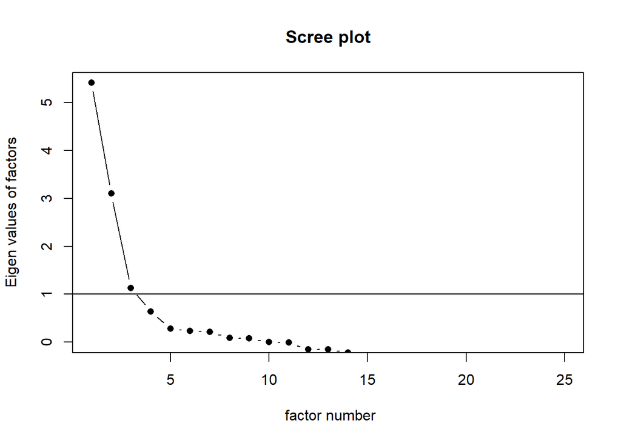

```r
# SDQ (25 items)
sdq <- d3 %>%
  select(sdq001_1:sdq025_1)

# Poly corr matrix
poly_sdq <- polychoric(sdq)
poly_sdq_mat <- data.frame(poly_sdq$rho)

# scree plot
scree(poly_sdq_mat,factors=TRUE,pc=FALSE,main="Scree plot",hline=NULL,add=FALSE)
```

```r
# EFA
fa(sdq, n.obs = NA, rotate = "none", fm = "uls", cor = "poly")
```

```
## Factor Analysis using method =  uls
## Call: fa(r = sdq, n.obs = NA, rotate = "none", fm = "uls", cor = "poly")
## Standardized loadings (pattern matrix) based upon correlation matrix
##           ULS1    h2   u2 com
## sdq001_1 -0.18 0.032 0.97   1
## sdq002_1  0.59 0.351 0.65   1
## sdq003_1  0.40 0.160 0.84   1
## sdq004_1 -0.12 0.014 0.99   1
## sdq005_1  0.70 0.492 0.51   1
## sdq006_1  0.22 0.048 0.95   1
## sdq007_1  0.44 0.190 0.81   1
## sdq008_1  0.62 0.388 0.61   1
## sdq009_1 -0.20 0.040 0.96   1
## sdq010_1  0.58 0.337 0.66   1
## sdq011_1  0.31 0.095 0.91   1
## sdq012_1  0.67 0.454 0.55   1
## sdq013_1  0.65 0.419 0.58   1
## sdq014_1  0.27 0.071 0.93   1
## sdq015_1  0.56 0.311 0.69   1
## sdq016_1  0.47 0.224 0.78   1
## sdq017_1 -0.38 0.146 0.85   1
## sdq018_1  0.59 0.347 0.65   1
## sdq019_1  0.51 0.256 0.74   1
## sdq020_1 -0.28 0.077 0.92   1
## sdq021_1  0.50 0.248 0.75   1
## sdq022_1  0.48 0.230 0.77   1
## sdq023_1  0.24 0.058 0.94   1
## sdq024_1  0.37 0.140 0.86   1
## sdq025_1  0.53 0.285 0.71   1
##
##                ULS1
## SS loadings    5.41
## Proportion Var 0.22
##
## Mean item complexity =  1
## Test of the hypothesis that 1 factor is sufficient.
##
## The degrees of freedom for the null model are  300  and the objective function was  11.73 with Chi Square of  4337.86
## The degrees of freedom for the model are 275  and the objective function was  7.38
##
## The root mean square of the residuals (RMSR) is  0.15
## The df corrected root mean square of the residuals is  0.16
##
## The harmonic number of observations is  361 with the empirical chi square  5161.84  with prob <  0
## The total number of observations was  380  with Likelihood Chi Square =  2722.86  with prob <  0
##
## Tucker Lewis Index of factoring reliability =  0.337
## RMSEA index =  0.153  and the 90 % confidence intervals are  0.148 0.159
## BIC =  1089.31
## Fit based upon off diagonal values = 0.66
## Measures of factor score adequacy
##                                                   ULS1
## Correlation of (regression) scores with factors   0.94
## Multiple R square of scores with factors          0.89
## Minimum correlation of possible factor scores     0.78
```

```
## In smc, smcs < 0 were set to .0
## In smc, smcs < 0 were set to .0
```

```
## In smc, smcs < 0 were set to .0
## In smc, smcs < 0 were set to .0
```

```
## In smc, smcs < 0 were set to .0
## In smc, smcs < 0 were set to .0
```

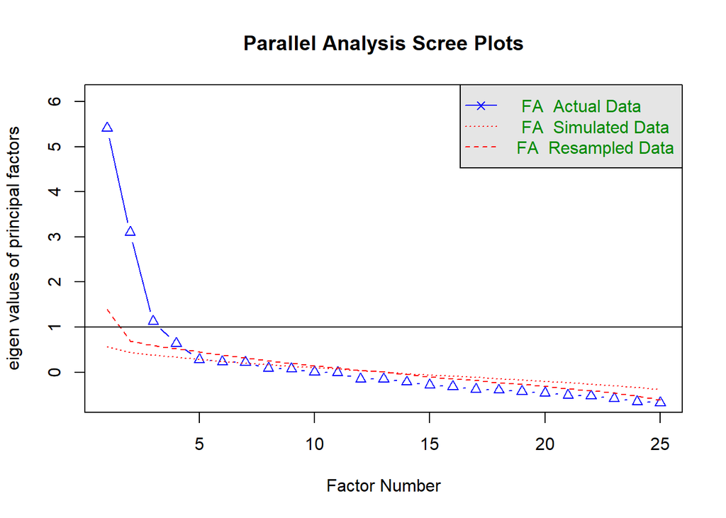

```
## Parallel analysis suggests that the number of factors =  4  and the number of components =  NA
```

```r
# PARALLEL ANALYSIS
fa.parallel(sdq, n.obs=NULL, fm="uls", fa="fa", nfactors=1, main="Parallel Analysis Scree Plots", n.iter=20, error.bars=FALSE, se.bars=FALSE, SMC=FALSE, ylabel=NULL, show.legend=TRUE, sim=TRUE, quant=.95, cor="poly", use="pairwise", plot=TRUE, correct=.5) # suggest 4 factors
```

```r
# 4 factors
fa(sdq, nfactors = 4, n.obs = NA, rotate = "quartimin", fm = "uls", cor = "poly")
```

```
## Factor Analysis using method =  uls
## Call: fa(r = sdq, nfactors = 4, n.obs = NA, rotate = "quartimin", fm = "uls",
##     cor = "poly")
## Standardized loadings (pattern matrix) based upon correlation matrix
##           ULS2  ULS3  ULS1  ULS4   h2   u2 com
## sdq001_1 -0.55 -0.01 -0.08  0.37 0.41 0.59 1.8
## sdq002_1  0.00 -0.04  0.69  0.14 0.53 0.47 1.1
## sdq003_1  0.02  0.37  0.19 -0.06 0.22 0.78 1.6
## sdq004_1 -0.51 -0.10  0.15  0.17 0.26 0.74 1.5
## sdq005_1  0.01  0.21  0.66  0.00 0.59 0.41 1.2
## sdq006_1 -0.02  0.51 -0.07 -0.14 0.25 0.75 1.2
## sdq007_1  0.56 -0.01  0.13  0.19 0.43 0.57 1.4
## sdq008_1  0.06  0.56  0.20  0.12 0.49 0.51 1.4
## sdq009_1 -0.71  0.04  0.10  0.06 0.48 0.52 1.1
## sdq010_1 -0.10 -0.09  0.85  0.03 0.66 0.34 1.0
## sdq011_1  0.64  0.13 -0.18  0.18 0.43 0.57 1.4
## sdq012_1  0.15  0.16  0.66 -0.14 0.57 0.43 1.3
## sdq013_1  0.04  0.60  0.19  0.17 0.56 0.44 1.4
## sdq014_1  0.72 -0.01 -0.06 -0.03 0.50 0.50 1.0
## sdq015_1 -0.10  0.33  0.27  0.44 0.53 0.47 2.7
## sdq016_1  0.01  0.74 -0.08  0.11 0.54 0.46 1.1
## sdq017_1 -0.70  0.17 -0.23  0.02 0.61 0.39 1.3
## sdq018_1  0.07  0.25  0.39  0.15 0.36 0.64 2.1
## sdq019_1  0.01  0.47  0.16  0.12 0.34 0.66 1.4
## sdq020_1 -0.57  0.15 -0.03 -0.22 0.43 0.57 1.4
## sdq021_1  0.37  0.02  0.23  0.31 0.39 0.61 2.7
## sdq022_1  0.32  0.23  0.35 -0.28 0.38 0.62 3.7
## sdq023_1  0.10  0.45 -0.10 -0.08 0.18 0.82 1.3
## sdq024_1 -0.15  0.80 -0.02 -0.13 0.64 0.36 1.1
## sdq025_1  0.33  0.11  0.13  0.52 0.52 0.48 1.9
##
##                       ULS2 ULS3 ULS1 ULS4
## SS loadings           3.63 3.30 3.14 1.23
## Proportion Var        0.15 0.13 0.13 0.05
## Cumulative Var        0.15 0.28 0.40 0.45
## Proportion Explained  0.32 0.29 0.28 0.11
## Cumulative Proportion 0.32 0.61 0.89 1.00
##
##  With factor correlations of
##       ULS2  ULS3 ULS1 ULS4
```

[output cut: 11 more lines]

```
## The root mean square of the residuals (RMSR) is  0.05
## The df corrected root mean square of the residuals is  0.06
##
## The harmonic number of observations is  361 with the empirical chi square  528.73  with prob <  3e-30
## The total number of observations was  380  with Likelihood Chi Square =  1083.43  with prob <  4.9e-119
##
## Tucker Lewis Index of factoring reliability =  0.681
## RMSEA index =  0.106  and the 90 % confidence intervals are  0.1 0.112
## BIC =  -140.24
## Fit based upon off diagonal values = 0.97
## Measures of factor score adequacy
##                                                   ULS2 ULS3 ULS1 ULS4
## Correlation of (regression) scores with factors   0.93 0.93 0.93 0.82
## Multiple R square of scores with factors          0.87 0.87 0.87 0.68
## Minimum correlation of possible factor scores     0.74 0.73 0.74 0.36
```

# SDQ withoutout prosocial scale

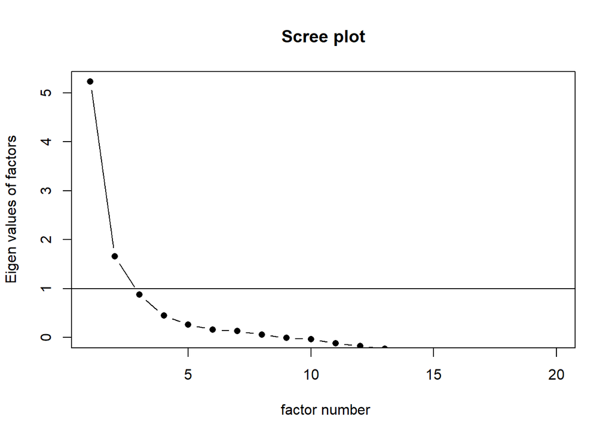

```r
# SDQ (25 items)
sdq_2 <- d3 %>%
  select(sdq001_1:sdq025_1) %>%
  select(-sdq001_1, -sdq004_1, -sdq009_1, -sdq017_1, -sdq020_1)

# Poly corr matrix
poly_sdq_2 <- polychoric(sdq_2)
poly_sdq_2_mat <- data.frame(poly_sdq_2$rho)

# scree plot
scree(poly_sdq_2_mat,factors=TRUE,pc=FALSE,main="Scree plot",hline=NULL,add=FALSE)
```

```r
# EFA
fa(sdq_2, n.obs = NA, rotate = "none", fm = "uls", cor = "poly")
```

```
## Factor Analysis using method =  uls
## Call: fa(r = sdq_2, n.obs = NA, rotate = "none", fm = "uls", cor = "poly")
## Standardized loadings (pattern matrix) based upon correlation matrix
##          ULS1    h2   u2 com
## sdq002_1 0.59 0.343 0.66   1
## sdq003_1 0.43 0.186 0.81   1
## sdq005_1 0.72 0.519 0.48   1
## sdq006_1 0.26 0.070 0.93   1
## sdq007_1 0.33 0.112 0.89   1
## sdq008_1 0.67 0.450 0.55   1
## sdq010_1 0.59 0.348 0.65   1
## sdq011_1 0.21 0.045 0.95   1
## sdq012_1 0.65 0.428 0.57   1
## sdq013_1 0.71 0.498 0.50   1
## sdq014_1 0.14 0.021 0.98   1
## sdq015_1 0.61 0.374 0.63   1
## sdq016_1 0.53 0.286 0.71   1
## sdq018_1 0.60 0.360 0.64   1
## sdq019_1 0.55 0.302 0.70   1
## sdq021_1 0.43 0.182 0.82   1
## sdq022_1 0.43 0.189 0.81   1
## sdq023_1 0.27 0.071 0.93   1
## sdq024_1 0.47 0.218 0.78   1
## sdq025_1 0.48 0.229 0.77   1
##
##                ULS1
## SS loadings    5.23
## Proportion Var 0.26
##
## Mean item complexity =  1
## Test of the hypothesis that 1 factor is sufficient.
##
## The degrees of freedom for the null model are  190  and the objective function was  8.37 with Chi Square of  3110.18
## The degrees of freedom for the model are 170  and the objective function was  4.11
##
## The root mean square of the residuals (RMSR) is  0.12
## The df corrected root mean square of the residuals is  0.13
##
## The harmonic number of observations is  362 with the empirical chi square  1944.48  with prob <  1.8e-298
## The total number of observations was  380  with Likelihood Chi Square =  1522.5  with prob <  9.4e-216
##
## Tucker Lewis Index of factoring reliability =  0.481
## RMSEA index =  0.145  and the 90 % confidence intervals are  0.138 0.152
## BIC =  512.67
## Fit based upon off diagonal values = 0.83
## Measures of factor score adequacy
##                                                   ULS1
## Correlation of (regression) scores with factors   0.94
## Multiple R square of scores with factors          0.89
## Minimum correlation of possible factor scores     0.79
```

```
## In smc, smcs < 0 were set to .0
## In smc, smcs < 0 were set to .0
```

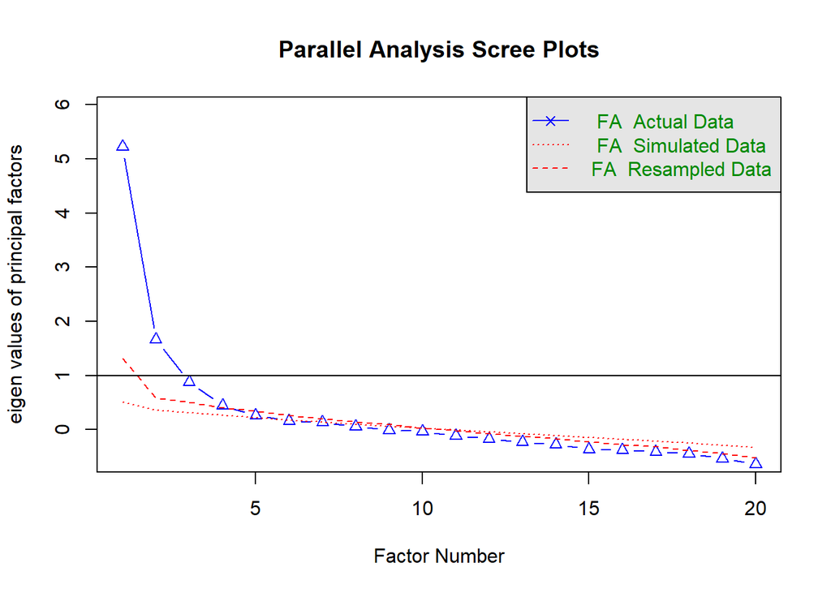

```
## Parallel analysis suggests that the number of factors =  5  and the number of components =  NA
```

```r
# PARALLEL ANALYSIS - without prosocial scale
fa.parallel(sdq_2, n.obs=NULL, fm="uls", fa="fa", nfactors=1, main="Parallel Analysis Scree Plots", n.iter=20, error.bars=FALSE, se.bars=FALSE, SMC=FALSE, ylabel=NULL, show.legend=TRUE, sim=TRUE, quant=.95, cor="poly", use="pairwise", plot=TRUE, correct=.5) # suggest 5 factors
```

```r
# 4 factors
fa(sdq_2, nfactors = 4, n.obs = NA, rotate = "quartimin", fm = "uls", cor = "poly")
```

```
## Factor Analysis using method =  uls
## Call: fa(r = sdq_2, nfactors = 4, n.obs = NA, rotate = "quartimin",
##     fm = "uls", cor = "poly")
## Standardized loadings (pattern matrix) based upon correlation matrix
##           ULS3  ULS1  ULS2  ULS4   h2   u2 com
## sdq002_1 -0.05  0.69  0.06  0.12 0.52 0.48 1.1
## sdq003_1  0.36  0.20  0.04 -0.14 0.23 0.77 1.9
## sdq005_1  0.20  0.66  0.02 -0.01 0.59 0.41 1.2
## sdq006_1  0.51 -0.05 -0.13 -0.08 0.25 0.75 1.2
## sdq007_1 -0.08  0.14  0.62  0.01 0.45 0.55 1.1
## sdq008_1  0.55  0.22  0.16 -0.05 0.49 0.51 1.5
## sdq010_1 -0.11  0.88 -0.10  0.04 0.69 0.31 1.1
## sdq011_1  0.03 -0.17  0.72  0.05 0.47 0.53 1.1
## sdq012_1  0.13  0.68  0.06 -0.16 0.56 0.44 1.2
## sdq013_1  0.59  0.20  0.17  0.00 0.55 0.45 1.4
## sdq014_1 -0.09 -0.07  0.69 -0.18 0.48 0.52 1.2
## sdq015_1  0.33  0.29  0.03  0.45 0.56 0.44 2.6
## sdq016_1  0.77 -0.09  0.00  0.18 0.61 0.39 1.1
## sdq018_1  0.22  0.40  0.11  0.17 0.38 0.62 2.1
## sdq019_1  0.48  0.13  0.11  0.07 0.34 0.66 1.3
## sdq021_1 -0.02  0.23  0.41  0.27 0.38 0.62 2.4
## sdq022_1  0.19  0.34  0.22 -0.38 0.38 0.62 3.1
## sdq023_1  0.41 -0.07  0.09 -0.12 0.17 0.83 1.3
## sdq024_1  0.82 -0.05 -0.16 -0.08 0.64 0.36 1.1
## sdq025_1  0.08  0.17  0.45  0.27 0.42 0.58 2.1
##
##                       ULS3 ULS1 ULS2 ULS4
## SS loadings           3.22 3.15 2.06 0.73
## Proportion Var        0.16 0.16 0.10 0.04
## Cumulative Var        0.16 0.32 0.42 0.46
## Proportion Explained  0.35 0.34 0.23 0.08
## Cumulative Proportion 0.35 0.70 0.92 1.00
##
##  With factor correlations of
##      ULS3 ULS1 ULS2 ULS4
## ULS3 1.00 0.38 0.10 0.11
## ULS1 0.38 1.00 0.30 0.18
## ULS2 0.10 0.30 1.00 0.05
## ULS4 0.11 0.18 0.05 1.00
##
## Mean item complexity =  1.6
## Test of the hypothesis that 4 factors are sufficient.
##
## The degrees of freedom for the null model are  190  and the objective function was  8.37 with Chi Square of  3110.18
## The degrees of freedom for the model are 116  and the objective function was  1.69
##
## The root mean square of the residuals (RMSR) is  0.05
## The df corrected root mean square of the residuals is  0.06
##
## The harmonic number of observations is  362 with the empirical chi square  295.13  with prob <  1.4e-17
## The total number of observations was  380  with Likelihood Chi Square =  622.57  with prob <  2.5e-70
##
## Tucker Lewis Index of factoring reliability =  0.714
## RMSEA index =  0.107  and the 90 % confidence intervals are  0.099 0.116
## BIC =  -66.49
## Fit based upon off diagonal values = 0.97
## Measures of factor score adequacy
##                                                   ULS3 ULS1 ULS2 ULS4
## Correlation of (regression) scores with factors   0.93 0.94 0.89 0.76
## Multiple R square of scores with factors          0.87 0.88 0.79 0.58
## Minimum correlation of possible factor scores     0.74 0.75 0.57 0.15
```